# Final Mile - Station (Grouped Data) Analysis

Tyler Yankee

2022-12-02

Load packages

```r
library(tidyverse)
library(here)
library(janitor)
library(lubridate)
library(sf)
library(tmap)
library(geojsonsf)
library(matrixStats)
library(geosphere)
bikeshare = read_csv(here("data_raw", "202209-capitalbikeshare-tripdata.zip")) %>%
  clean_names() %>% mutate(start_station_name = case_when(
    start_station_name == "11th & V st NW" ~ "11th & V St NW",
    TRUE ~ start_station_name
  ), end_station_name = case_when(
    end_station_name == "11th & V st NW" ~ "11th & V St NW",
    TRUE ~ end_station_name
  ))
```

```
Multiple files in zip: reading '202209-capitalbikeshare-tripdata.csv'
```

```r
metro_stations = read_csv(here("data_raw", "dc_metro_stations.csv")) %>%
  clean_names()
metro_stations_sf = geojson_sf(here("data_raw", "dc_metro_stations.geojson")) %>%
  clean_names() %>% select(close_station = name, metro_location = geometry)
```

NOTE: the following several code chunks are copied directly from FinalMileOriginal.Rmd.

Define the Haversine distance function so we can compute distance between things

```r
# This function takes five arguments:
#
# Longitude and latitude of the first location
# Longitude and latitude of the second location
# A parameter by which to round the responses

haversine <- function(long1, lat1, long2, lat2, round = 3) {
  # convert to radians
  long1 = long1 * pi / 180
  lat1  = lat1  * pi / 180
  long2 = long2 * pi / 180
  lat2  = lat2  * pi / 180

  R = 6371 # Earth mean radius in km

  a = sin((lat2 - lat1)/2)^2 + cos(lat1) * cos(lat2) * sin((long2 - long1)/2)^2
  d = R * 2 * asin(sqrt(a))

  return( round(d,round) ) # distance in km
}
```

```r
bikeshare1 = bikeshare %>% select(ride_id, slat = start_lat, slng = start_lng,
                                  bikeshare_start_station = start_station_name) %>% na.omit()
metro_stations1 = metro_stations %>% select(end_station_name = name, lat = y, lng = x) %>% na.omit()
```

https://stackoverflow.com/questions/58831578/minimum-distance-between-lat-long-across-multiple-data-frames Finds the closest station to bikes endpoint, adds station name and distance to the bikshare dataframe.

```r
#calculate the distance matrix
distmatrix<-distm(bikeshare1[, c(3, 2)], metro_stations1[,c(3, 2)])
#find closest column and get distance
closest<-apply(distmatrix, 1, which.min)
bikeshare1$close_station <- as.character(metro_stations1$end_station_name[closest])
bikeshare1$distance <- apply(distmatrix, 1, min)/1000
```

Counts the amount of bikes parked within 0.1524/500ft, close enough to consider bike being used for final mile.

```r
final_mile = bikeshare1 %>% filter(distance < 0.1524)
bikeshare_end = bikeshare %>% select(ride_id, elat = end_lat, elng = end_lng)
new = left_join(final_mile, bikeshare_end, by = "ride_id")
```

```r
final_mile1 = new %>% mutate(start_to_end = haversine(slng, slat, elng, elat))
final_mile1 = final_mile1 %>% filter(start_to_end <= 1.60934 & start_to_end != 0) %>%
  select(ride_id, close_station, distance, start_to_end, bikeshare_start_station)
```

Make all of the data frames that we’ll use for analysis.

```r
final_mile1_grouped = final_mile1 %>% group_by(close_station) %>%
  summarise(count = n(), avg_distance_to_bikeshare = mean(distance),
            avg_ride_distance = mean(start_to_end))
final_mile1_geo = left_join(final_mile1_grouped, metro_stations_sf, by="close_station")
final_mile1_geo = st_as_sf(x = final_mile1_geo, crs = st_crs(metro_stations_sf))
```

NEW ANALYSIS BEGINS HERE

Again, from FinalMileOriginal, here are the main goals of the following analysis:

- Analyze grouped data frame through distributions and comparing counts and average distances.
- Visualizations: lines from start to end point for final mile rides, density distributions from above.

Visualization: simple bar plot for number of final mile rides per metro station.

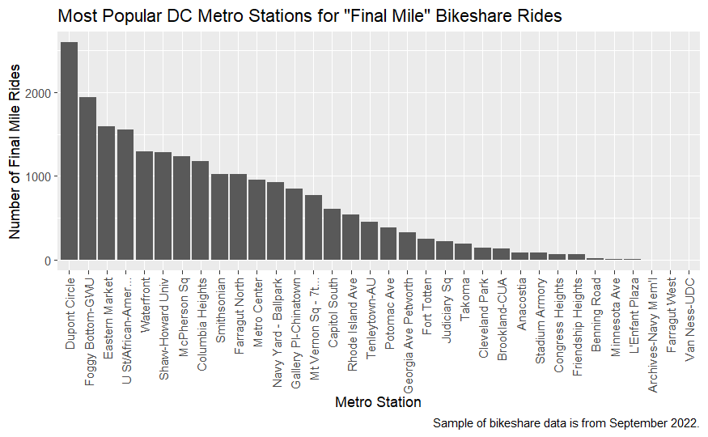

```r
final_mile1_grouped %>% ggplot(aes(x = reorder(close_station, -count))) +
  geom_bar(aes(weight = count)) +
  theme(axis.text.x = element_text(angle = 90, vjust = 0.5, hjust=1)) +
  labs(title = "Most Popular DC Metro Stations for \"Final Mile\" Bikeshare Rides",
       x = "Metro Station",
       y = "Number of Final Mile Rides",
       caption = "Sample of bikeshare data is from September 2022.") +
  scale_x_discrete(label = function(x) stringr::str_trunc(x, 20))
```

As someone who doesn’t know the DC area very well, I don’t have that many observations here - I think the spatial viz down below where it shows these counts on the map is more useful.

Visualization: simple histogram for 1) average distance from metro station to bikeshare station 2) average distance ridden on the subsequent bike ride

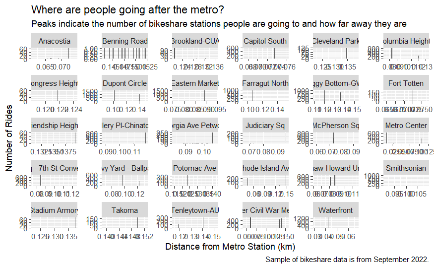

```r
# Filter out the stations which have little to no rides - their distributions are garbage
final_mile_stations = pull(final_mile1_grouped %>% filter(count > 10) %>%
  select(close_station), close_station)
final_mile1 %>% filter(close_station %in% final_mile_stations) %>%
  ggplot(aes(x = distance)) +
  geom_histogram(bins = 75) +
  facet_wrap(~close_station, scales = "free") +
  labs(title = "Where are people going after the metro?",
       subtitle = "Peaks indicate the number of bikeshare stations people are going to and how far away they are",
       x = "Distance from Metro Station (km)",
       y = "Number of Rides",
       caption = "Sample of bikeshare data is from September 2022.")
```

The fact that these distributions look weird actually makes sense - the number of peaks on each histogram (most are just 1, but some 2 or 3) correspond to the number of close bikeshare stations that people are going to. Looking at average distance ridden on the bike after that will probably be a more interesting result.

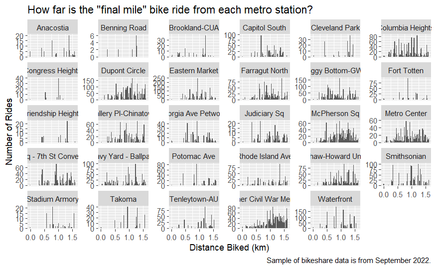

```r
final_mile1 %>% filter(close_station %in% final_mile_stations) %>%
  ggplot(aes(x = start_to_end)) +
  geom_histogram(bins = 75) +
  facet_wrap(~close_station, scales = "free_y") +
  labs(title = "How far is the \"final mile\" bike ride from each metro station?",
       x = "Distance Biked (km)",
       y = "Number of Rides",
       caption = "Sample of bikeshare data is from September 2022.")
```

Compare the average ride distance computed from the final_mile1_grouped dataframe using a lollipop plot, which is useful for when you have one numeric and one categorical variable.

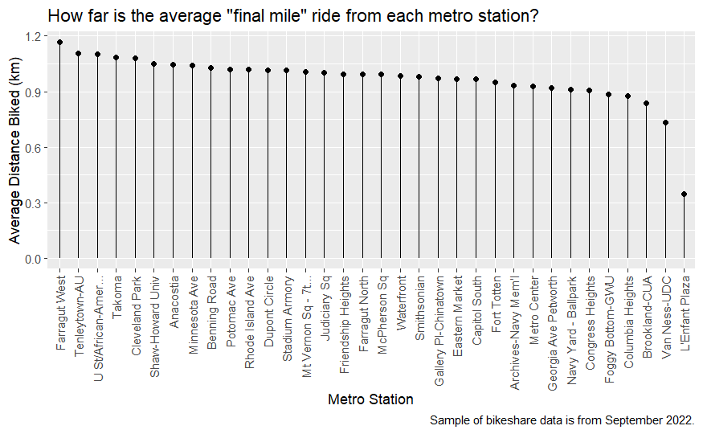

```r
final_mile1_grouped %>% ggplot(aes(x = reorder(close_station,-avg_ride_distance),
                                   y = avg_ride_distance)) +
  geom_point() +
  geom_segment(aes(x = close_station, xend = close_station, y = 0, yend = avg_ride_distance)) +
  theme(axis.text.x = element_text(angle = 90, vjust = 0.5, hjust=1)) +
  labs(title = "How far is the average \"final mile\" ride from each metro station?",
       x = "Metro Station",
       y = "Average Distance Biked (km)",
       caption = "Sample of bikeshare data is from September 2022.") +
  scale_x_discrete(label = function(x) stringr::str_trunc(x, 20))
```

## Spatial Visualizations

This viz shows the same information as the one above titled “Most Popular DC Metro Stations for ‘Final Mile’ Bikeshare Rides”, but on a map instead of a simple bar chart.

```r
tmap_mode("view")
```

```
tmap mode set to interactive viewing
```

```r
tm_basemap(c(StreetMap = "OpenStreetMap")) + tm_shape(final_mile1_geo) +
  tm_dots(size = "count", alpha = .25)
```

```
Legend for symbol sizes not available in view mode.
```

[interactive chart not shown]

It makes sense that the metro stations around the more populated working area of DC have more bikeshare rides near them. Interesting to note, though, that each individual metro station still has more close bikeshare rides despite the fact that there are more of them in a smaller area than the ones towards the outskirts.

Code from https://gis.stackexchange.com/questions/419232/create-sf-points-and-then-lines-from-4-columns-in-a-data-frame-while-staying-in to make a line geometry in a dataframe in sf given 4 columns representing (x1,y1)->(x2,y2)

```r
make_line <- function(xy2){
    st_linestring(matrix(xy2, nrow=2, byrow=TRUE))
}

make_lines <- function(df, names=c("x1","y1","x2","y2")){
    m = as.matrix(df[,names])
    lines = apply(m, 1, make_line, simplify=FALSE)
    st_sfc(lines)
}

sf_pts_to_lines <- function(df, names=c("x1","y1","x2","y2")){
    geom = make_lines(df, names)
    df = st_sf(df, geometry=geom)
    df
}
```

Manipulate data frames to get all “final mile” pairings; that is, all lines between bikeshare stations and metro stations which are less than 500 ft apart.

```r
stations = bikeshare %>% select(bikeshare_start_station = start_station_name,
                                start_lng, start_lat) %>%
  group_by(bikeshare_start_station) %>%
  summarise(blng = mean(start_lng), blat = mean(start_lat)) %>%
  mutate(across(where(is.numeric), round, 3))
metro_stations_separate = metro_stations_sf %>% mutate(
  mlng = unlist(map(metro_location,1)), mlat = unlist(map(metro_location,2))) %>%
  st_drop_geometry() %>%
  mutate(across(where(is.numeric), round, 3))
final_mile2 = new %>% mutate(start_to_end = haversine(slng, slat, elng, elat)) %>%
  filter(start_to_end <= 1.60934 & start_to_end != 0) %>%
  select(bikeshare_start_station, close_station) %>%
  group_by(bikeshare_start_station, close_station) %>%
  summarise(count = n()) %>%
  left_join(metro_stations_separate, by="close_station") %>%
  left_join(stations, by="bikeshare_start_station") %>%
  sf_pts_to_lines(c("blng","blat","mlng","mlat"))
```

Visualize these results.

```r
tm_shape(final_mile2) + tm_lines(lwd="count", scale = 5) +
  tm_layout(title = "Metro Stations and Bikeshare Stations Within 500 ft of Each Other")
```

[interactive chart not shown]

I think the main difference between what we can see with this map versus the other one is not only where the nearby bikeshare stations are, but also if there are multiple (e.g., Dupont Circle, Foggy Bottom). Columbia Heights is actually a really interesting example of this, where there are two nearby bikeshare stations but one gets used a good deal more than the other.

## Output data

Write some of our dataframes to csv for potential future use by others.

```r
final_mile1 %>% rename("close_metro_station" = "close_station",
                                     "dist_metro_to_bikeshare" = "distance",
                                     "bike_ride_dist" = "start_to_end") %>%
  write_csv(file = here("data", "final_mile_rides.csv"), append = FALSE)
final_mile1_grouped %>%
  rename("close_metro_station" = "close_station",
         "num_rides" = "count") %>%
  write_csv(file = here("data", "final_mile_metro.csv"), append = FALSE)
final_mile1_geo %>% rename("close_metro_station" = "close_station",
                                                  "num_rides" = "count") %>%
  st_write(here("data", "final_mile_metro.geojson"), append = FALSE)
```

```
Deleting layer not supported by driver `GeoJSON'
Deleting layer `final_mile_metro' failed
Writing layer `final_mile_metro' to data source
  `C:/Users/tsyan/Repos/DS241-Class-Project/data/final_mile_metro.geojson' using driver `GeoJSON'
Updating existing layer final_mile_metro
Writing 34 features with 4 fields and geometry type Point.
```

```r
final_mile2 %>% select(-mlat, -mlng, -blat, -blng) %>%
  rename("close_metro_station" = "close_station",
         "num_rides" = "count",
         "metro_to_bikeshare" = "geometry") %>%
  st_write(here("data", "close_metro_bikeshare_stations.geojson"), append = FALSE)
```

```
Deleting layer not supported by driver `GeoJSON'
Deleting layer `close_metro_bikeshare_stations' failed
Writing layer `close_metro_bikeshare_stations' to data source
  `C:/Users/tsyan/Repos/DS241-Class-Project/data/close_metro_bikeshare_stations.geojson' using driver `GeoJSON'
Updating existing layer close_metro_bikeshare_stations
Writing 46 features with 3 fields and geometry type Line String.
```